# Chapter 10 Problem Set Solutions

```r
library(ggplot2)
library(readxl)
library(caret)
library(gains)
library(rpart)
library(rpart.plot)
library(pROC)
library(randomForest)
library(adabag)
```

# WARNING: If you’re using a version of R that is 3.6 or larger, then Connect is going to mark your answers as incorrect, even if they are correct. This is because R updated the way they generate random numbers, so the set.seed() function generates different random numbers than the version of R used in the textbook. Since these problem set grades do not factor into the final grade, don’t worry about this. We will use the new random numbers, so the Connect solutions will be different.

### 10.1

```r
myData = read_xlsx("Ch10_Q1_Data_File.xlsx")
```

To calculate min and max split values, sort by the respective variable and then average out the two largest and two smallest pairs of observations.

```r
agesort = order(myData$Age)
myDataAge = myData[agesort,]
mean(myDataAge$Age[7:8])
```

```
[1] 51
```

```r
mean(myDataAge$Age[1:2])
```

```
[1] 27
```

```r
incsort = order(myData$Income)
myDataInc = myData[incsort,]
mean(myDataInc$Income[7:8])
```

```
[1] 99000
```

```r
mean(myDataInc$Income[1:2])
```

```
[1] 39250
```

### 10.2

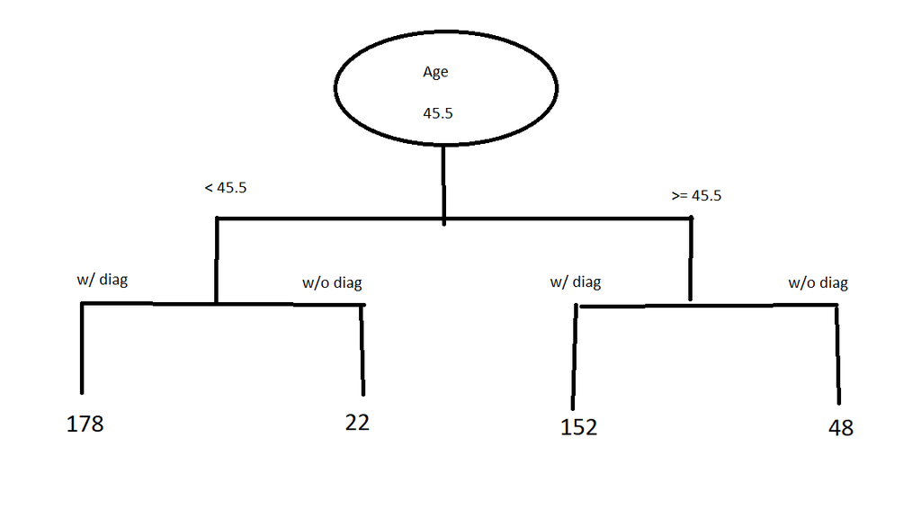

Tree

At root node, there are 330 (178+152) observations with a diagnosis and 70 (22+48) observations without a diagnosis. Thus, the Gini index is calculated as such:

```r
1 - ((70/400)^2+(330/400)^2)
```

```
[1] 0.28875
```

At the $Age<45.5$ partition, there are 178 observations with a diagnosis and 22 observations without a diagnosis. Thus, the Gini index is calculated as such:

```r
1 - ((22/200)^2+(178/200)^2)
```

```
[1] 0.1958
```

At the $Age\geq45.5$ partition, there are 152 observations with a diagnosis and 48 observations without a diagnosis. Thus, the Gini index is calculated as such:

```r
1 - ((48/200)^2+(152/200)^2)
```

```
[1] 0.3648
```

For the split, there are 200 observations on either side of the age split. Thus, we weight each of the partition’s Gini index by 0.5 (200/400).

```r
0.5*(1 - ((22/200)^2+(178/200)^2)) + 0.5*(1 - ((48/200)^2+(152/200)^2))
```

```
[1] 0.2803
```

### 10.3

```r
myData = read_xlsx("Ch10_Q9_Data_File.xlsx")
myScoreData = read_xlsx("Ch10_Q9_Score_File.xlsx")
```

First, save $y$ as factor. Then partition data. The rpart function generates the default classification tree and prp plots the outputted tree. The “class” method is the default for a factor variable, so technically not necessary. The summary of the tree outputs the details for each node in the tree (note: the node numbers jump from 7 to 12, because there are no children to nodes 4 or 5, but those are labeled as 8-11 internally).

```r
myData$y <- as.factor(myData$y)
set.seed(1)
myIndex <- createDataPartition(myData$y, p=0.7, list=FALSE)
trainSet <- myData[myIndex,]
```

```
The `i` argument of ``[`()` can't be a matrix as of tibble 3.0.0.
Convert to a vector.
```

```r
validationSet <- myData[-myIndex,]
set.seed(1)
default_tree <- rpart(y~., data = trainSet, method = "class")
summary(default_tree)
```

```
Call:
rpart(formula = y ~ ., data = trainSet, method = "class")
  n= 141

          CP nsplit rel error    xerror       xstd
1 0.76811594      0 1.0000000 1.2753623 0.08335288
2 0.04347826      1 0.2318841 0.2898551 0.06004115
3 0.01449275      2 0.1884058 0.2898551 0.06004115
4 0.01000000      4 0.1594203 0.3188406 0.06244910

Variable importance
x5 x2 x4 x1 x3
34 21 20 19  5

Node number 1: 141 observations,    complexity param=0.7681159
  predicted class=1  expected loss=0.4893617  P(node) =1
    class counts:    69    72
   probabilities: 0.489 0.511
  left son=2 (67 obs) right son=3 (74 obs)
  Primary splits:
      x5 < 15.82    to the right, improve=42.119960, (0 missing)
      x2 < 208.13   to the right, improve=27.150270, (0 missing)
      x4 < 144.835  to the right, improve=23.512530, (0 missing)
      x1 < 68.71874 to the right, improve=17.945400, (0 missing)
      x3 < 0.5      to the left,  improve= 2.731651, (0 missing)
  Surrogate splits:
      x2 < 198.25   to the right, agree=0.830, adj=0.642, (0 split)
      x4 < 144.835  to the right, agree=0.816, adj=0.612, (0 split)
      x1 < 68.71874 to the right, agree=0.801, adj=0.582, (0 split)
      x3 < 0.5      to the right, agree=0.539, adj=0.030, (0 split)

Node number 2: 67 observations,    complexity param=0.04347826
  predicted class=0  expected loss=0.1044776  P(node) =0.4751773
    class counts:    60     7
   probabilities: 0.896 0.104
  left son=4 (60 obs) right son=5 (7 obs)
  Primary splits:
      x3 < 0.5      to the left,  improve=5.813504, (0 missing)
      x4 < 109.335  to the right, improve=1.638490, (0 missing)
      x5 < 19.345   to the right, improve=1.332185, (0 missing)
```

[output cut: 42 more lines]

```

Node number 7: 48 observations
  predicted class=1  expected loss=0  P(node) =0.3404255
    class counts:     0    48
   probabilities: 0.000 1.000

Node number 12: 8 observations
  predicted class=0  expected loss=0.375  P(node) =0.05673759
    class counts:     5     3
   probabilities: 0.625 0.375

Node number 13: 18 observations
  predicted class=1  expected loss=0.2222222  P(node) =0.1276596
    class counts:     4    14
   probabilities: 0.222 0.778
```

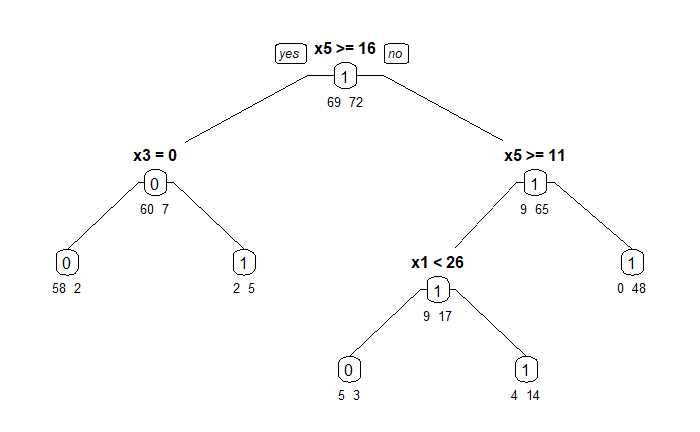

```r
prp(default_tree, type = 1, extra = 1, under = TRUE)
```

With this default tree, we have 5 terminal leaf nodes. The root split is for $x_5$ at 15.82 (the figure rounds up to 16 and the solution in Connect splits at 20).

To build the full tree, we need to insert a few options to the rpart function. First, the cp=0 sets the threshold for the complexity parameter to 0. This means that if a split provides *any* additional benefit ($>cp$), it will be included in the tree. This complexity parameter controls the amount of *pruning* for the tree. In other words, if a split does not add any meaningful benefit in terms of predictive performance (determined by cp), then that node would not be split. By setting this to 0, we include all possible splits. Then the minsplit=2 indicates the minimum number of observations in a node for the algorithm to attempt a split (setting this to 2 ensures that every distinct observation be split). Lastly, minbucket indicates the minimum number of observations in any terminal node. We set this to 1 because we want the full tree.

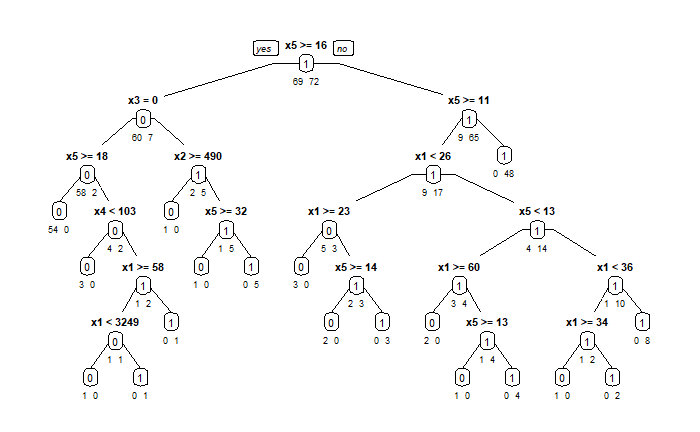

```r
set.seed(1)
full_tree <- rpart(y ~ ., data = trainSet, method = "class", cp = 0, minsplit = 2, minbucket = 1)
prp(full_tree, type = 1, extra = 1, under = TRUE)
```

To examine the complexity parameter’s decline as we add more splits to the tree, we use printcp to output its progression. As we include more splits, the CP reduces down to 0 at the full tree. The relative error (in-sample) also reduces to 0. The xerror and xstd give you the cross-validation errors and standard deviations. The minimum xerror is achieved with 2 splits and has a CP=0.0144928 (Connect has 0.0217 CP with 1 split).

```r
printcp(full_tree)
```

```
Classification tree:
rpart(formula = y ~ ., data = trainSet, method = "class", cp = 0,
    minsplit = 2, minbucket = 1)

Variables actually used in tree construction:
[1] x1 x2 x3 x4 x5

Root node error: 69/141 = 0.48936

n= 141

         CP nsplit rel error  xerror     xstd
1 0.7681159      0  1.000000 1.27536 0.083353
2 0.0434783      1  0.231884 0.28986 0.060041
3 0.0144928      2  0.188406 0.24638 0.056037
4 0.0072464     11  0.043478 0.36232 0.065726
5 0.0000000     17  0.000000 0.34783 0.064676
```

The “best-pruned” tree is determined by selecting the “simplest tree within one standard error of the cross-validation error of the minimum tree.” This means that we take the minimum xerror of 0.24638 and look for the tree with the fewest splits that also has a xerror $<0.302417$ or $0.24638+0.056037$. Since the xerror with just 1 split is 0.28986, this is sufficiently accurate and is considered the best-pruned tree.

We can also use the prune function to trim down the full tree to a specified CP level. Thus, if we set the CP=0.0144928 of the minimum error tree, then it does the pruning for us.

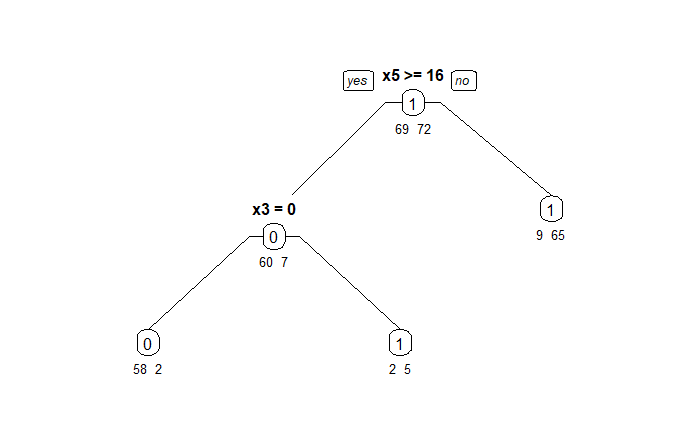

```r
pruned_tree <- prune(full_tree, cp = 0.0144928)
prp(pruned_tree, type = 1, extra = 1, under = TRUE)
```

Since our minimum error tree has 2 splits, this means there are 3 terminal (leaf) nodes. Connect’s solution only has 1 split and 2 terminal nodes.

Predict the class for the validation set and compute confusion matrix.

```r
predicted_class <- predict(pruned_tree, validationSet, type = "class")
confusionMatrix(predicted_class, validationSet$y, positive = "1")
```

```
Confusion Matrix and Statistics

          Reference
Prediction  0  1
         0 19 11
         1 10 19

               Accuracy : 0.6441
                 95% CI : (0.5087, 0.7645)
    No Information Rate : 0.5085
    P-Value [Acc > NIR] : 0.02481

                  Kappa : 0.2883

 Mcnemar's Test P-Value : 1.00000

            Sensitivity : 0.6333
            Specificity : 0.6552
         Pos Pred Value : 0.6552
         Neg Pred Value : 0.6333
             Prevalence : 0.5085
         Detection Rate : 0.3220
   Detection Prevalence : 0.4915
      Balanced Accuracy : 0.6443

       'Positive' Class : 1
```

Predict the estimated class probabilities using the type=‘prob’ option. Then calculate gains table and plot lift charts.

```r
predicted_prob <- predict(pruned_tree, newdata=validationSet, type= 'prob')
validationSet$y <- as.numeric(as.character(validationSet$y))
gains_table <- gains(validationSet$y, predicted_prob[,2])
gains_table
```

```
Depth                            Cume   Cume Pct                     Mean
 of           Cume     Mean      Mean   of Total    Lift   Cume     Model
File     N      N      Resp      Resp      Resp    Index   Lift     Score
-------------------------------------------------------------------------
  47    28     28      0.68      0.68      63.3%     133    133      0.88
  49     1     29      0.00      0.66      63.3%       0    129      0.71
 100    30     59      0.37      0.51     100.0%      72    100      0.03
```

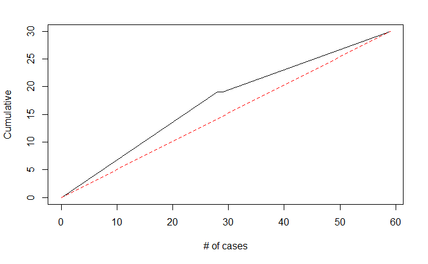

```r
plot(c(0, gains_table$cume.pct.of.total*sum(validationSet$y)) ~ c(0, gains_table$cume.obs), xlab = '# of cases', ylab = "Cumulative", type = "l")
lines(c(0, sum(validationSet$y))~c(0, dim(validationSet)[1]), col="red", lty=2)
```

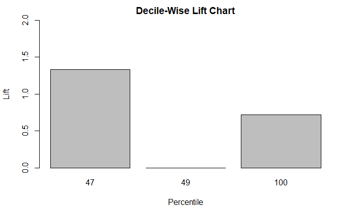

```r
barplot(gains_table$mean.resp/mean(validationSet$y), names.arg=gains_table$depth, xlab="Percentile", ylab="Lift", ylim=c(0, 2.0), main="Decile-Wise Lift Chart")
```

Then plot the ROC curve and calculate the AUC.

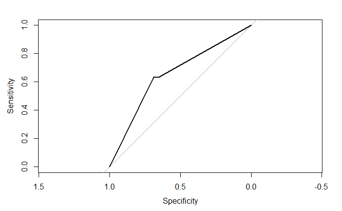

```r
roc_object <- roc(validationSet$y, predicted_prob[,2])
plot.roc(roc_object)
```

```r
auc(roc_object)
```

```
Area under the curve: 0.6552
```

Predict the binary response for the scoring dataset. Then predict the estimated probabilities of class assignment for each outcome. The first scored response is predicted to be a “true” response (or 1). More specifically, it is given a 0.878 probability of belonging to the “true” group, and the decision rule classifies that as a predicted “true”.

```r
predicted_class_score <- predict(pruned_tree, myScoreData, type = "class")
predicted_class_score
```

```
1 2 3 4 5
1 1 1 0 1
Levels: 0 1
```

```r
predicted_class_prob <- predict(pruned_tree, myScoreData, type = "prob")
predicted_class_prob
```

```
          0          1
1 0.1216216 0.87837838
2 0.1216216 0.87837838
3 0.1216216 0.87837838
4 0.9666667 0.03333333
5 0.1216216 0.87837838
```

### 10.4

```r
myData = read_xlsx("Ch10_Q18_Data_File.xlsx")
myScoreData = read_xlsx("Ch10_Q18_Score_File.xlsx")
```

First, reformat App as factor variable. Then partition data and fit regression tree to the training set for predicting whether a customer is interested in the app. Default tree has 14 terminal nodes, and the root split is for an education level 2 or higher. Connect has the same number of terminal nodes, but their root split is for Age at 44.

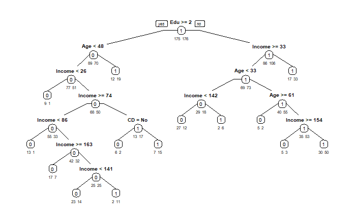

```r
myData$App <- as.factor(myData$App)
set.seed(1)
myIndex <- createDataPartition(myData$App, p=0.7, list=FALSE)
trainSet <- myData[myIndex,]
validationSet <- myData[-myIndex,]
set.seed(1)
default_tree <- rpart(App ~., data = trainSet, method = "class")
prp(default_tree, type = 1, extra = 1, under = TRUE)
```

Set parameters to generate full tree and compute CP table.

```r
set.seed(1)
full_tree <- rpart(App ~ ., data = trainSet, method = "class", cp = 0, minsplit = 2, minbucket = 1)
printcp(full_tree)
```

```
Classification tree:
rpart(formula = App ~ ., data = trainSet, method = "class", cp = 0,
    minsplit = 2, minbucket = 1)

Variables actually used in tree construction:
[1] Age    CD     Edu    Gender Income

Root node error: 175/351 = 0.49858

n= 351

          CP nsplit rel error  xerror     xstd
1  0.1085714      0  1.000000 1.20000 0.052484
2  0.0400000      1  0.891429 1.15429 0.052915
3  0.0257143      2  0.851429 1.00000 0.053528
4  0.0142857      6  0.748571 0.96571 0.053492
5  0.0114286     12  0.662857 0.99429 0.053527
6  0.0095238     17  0.605714 1.00571 0.053528
7  0.0085714     26  0.497143 1.02286 0.053518
8  0.0068571     34  0.428571 1.02286 0.053518
9  0.0057143     39  0.394286 1.02857 0.053511
10 0.0045714     68  0.228571 1.03429 0.053502
11 0.0038095     75  0.194286 1.02857 0.053511
12 0.0028571     81  0.171429 1.03429 0.053502
13 0.0019048    135  0.011429 1.03429 0.053502
14 0.0000000    141  0.000000 1.03429 0.053502
```

Our minimum error tree has 6 splits and a CP value of 0.0142857. Connect has 4 splits and a CP=0.0086.

The threshold for being within one standard error of the minimum xerror is 1.019202 (0.96571+0.053492). The simplest tree under this threshold is the one with 2 splits and a CP=0.0257143.

Prune the full tree down to a CP equal to that of the best-pruned tree. Then predict validation set outcomes (predict whether the customer is interested in the app or not) and compute the confusion matrix and predictive performance metrics.

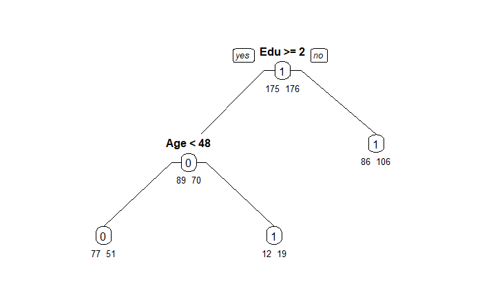

```r
pruned_tree <- prune(full_tree, cp = 0.0257143)
prp(pruned_tree, type = 1, extra = 1, under = TRUE)
```

```r
predicted_class <- predict(pruned_tree, validationSet, type = "class")
confusionMatrix(predicted_class, validationSet$App, positive = "1")
```

```
Confusion Matrix and Statistics

          Reference
Prediction  0  1
         0 25 29
         1 49 46

               Accuracy : 0.4765
                 95% CI : (0.3941, 0.5598)
    No Information Rate : 0.5034
    P-Value [Acc > NIR] : 0.76950

                  Kappa : -0.0489

 Mcnemar's Test P-Value : 0.03145

            Sensitivity : 0.6133
            Specificity : 0.3378
         Pos Pred Value : 0.4842
         Neg Pred Value : 0.4630
             Prevalence : 0.5034
         Detection Rate : 0.3087
   Detection Prevalence : 0.6376
      Balanced Accuracy : 0.4756

       'Positive' Class : 1
```

Compute the predicted probabilities of a customer being interested in the app for the validation set. Then compute gains table and plot lift chart.

```r
predicted_prob <- predict(pruned_tree, newdata=validationSet, type= 'prob')
validationSet$App <- as.numeric(as.character(validationSet$App))
gains_table <- gains(validationSet$App, predicted_prob[,2])
gains_table
```

```
Depth                            Cume   Cume Pct                     Mean
 of           Cume     Mean      Mean   of Total    Lift   Cume     Model
File     N      N      Resp      Resp      Resp    Index   Lift     Score
-------------------------------------------------------------------------
   9    14     14      0.64      0.64      12.0%     128    128      0.61
  64    81     95      0.46      0.48      61.3%      91     96      0.55
 100    54    149      0.54      0.50     100.0%     107    100      0.40
```

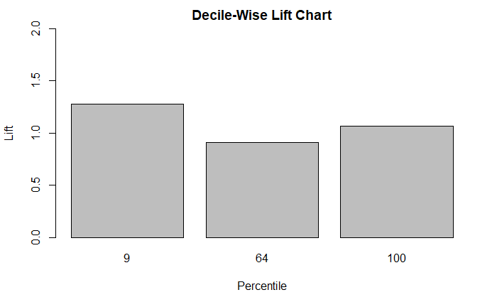

```r
barplot(gains_table$mean.resp/mean(validationSet$App), names.arg=gains_table$depth, xlab="Percentile", ylab="Lift", ylim=c(0, 2), main="Decile-Wise Lift Chart")
```

Plot the ROC curve and compute AUC.

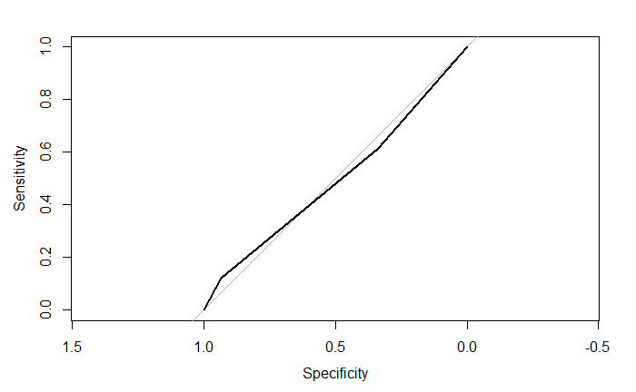

```r
roc_object <- roc(validationSet$App, predicted_prob[,2])
plot.roc(roc_object)
```

```r
auc(roc_object)
```

```
Area under the curve: 0.4946
```

Score new observations.

```r
predicted_class_score <- predict(pruned_tree, myScoreData, type = "class")
predicted_class_score
```

```
 1  2  3  4  5  6  7  8  9 10 11 12 13 14 15 16 17 18 19 20
 1  1  1  0  1  1  1  0  1  1  1  1  1  1  0  0  0  1  1  0
Levels: 0 1
```

```r
predicted_class_prob <- predict(pruned_tree, myScoreData, type = "prob")
predicted_class_prob
```

```
           0         1
1  0.4479167 0.5520833
2  0.3870968 0.6129032
3  0.4479167 0.5520833
4  0.6015625 0.3984375
5  0.4479167 0.5520833
6  0.3870968 0.6129032
7  0.4479167 0.5520833
8  0.6015625 0.3984375
9  0.4479167 0.5520833
10 0.4479167 0.5520833
11 0.3870968 0.6129032
12 0.4479167 0.5520833
13 0.3870968 0.6129032
14 0.4479167 0.5520833
15 0.6015625 0.3984375
16 0.6015625 0.3984375
17 0.6015625 0.3984375
18 0.3870968 0.6129032
19 0.3870968 0.6129032
20 0.6015625 0.3984375
```

### 10.5

```r
myData = read_xlsx("Ch10_Q44_Data_File.xlsx")
```

Preliminary work:

```r
myData$y <- as.factor(myData$y)
set.seed(1)
myIndex <- createDataPartition(myData$y, p=0.6, list=FALSE)
trainSet <- myData[myIndex,]
validationSet <- myData[-myIndex,]
set.seed(1)
```

Use the randomForest function and set mtry to the number of predictor variables to run a bagging ensemble model. If you set mtry to a value less than the number of predictor variables, that random forest model will also mix up which predictors are used in different trees. The ntree option indicates that 100 single-tree models will be generated and averaged across.

```r
bagging_tree <- randomForest(y ~., data = trainSet, ntree = 100, mtry = 4, importance = TRUE)
predicted_class <- predict(bagging_tree, validationSet)
confusionMatrix(predicted_class, validationSet$y, positive = "1")
```

```
Confusion Matrix and Statistics

          Reference
Prediction  0  1
         0 24  3
         1  1  3

               Accuracy : 0.871
                 95% CI : (0.7017, 0.9637)
    No Information Rate : 0.8065
    P-Value [Acc > NIR] : 0.2563

                  Kappa : 0.5267

 Mcnemar's Test P-Value : 0.6171

            Sensitivity : 0.50000
            Specificity : 0.96000
         Pos Pred Value : 0.75000
         Neg Pred Value : 0.88889
             Prevalence : 0.19355
         Detection Rate : 0.09677
   Detection Prevalence : 0.12903
      Balanced Accuracy : 0.73000

       'Positive' Class : 1
```

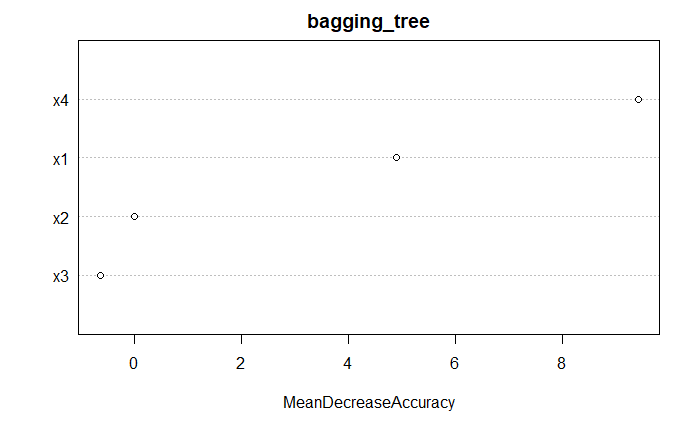

```r
varImpPlot(bagging_tree,type=1)
```

Plot ROC curve and compute AUC.

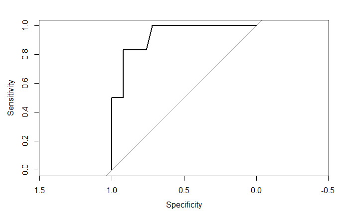

```r
predicted_prob <- predict(bagging_tree, newdata=validationSet, type= 'prob')
roc_object <- roc(validationSet$y, predicted_prob[,2])
plot.roc(roc_object)
```

```r
auc(roc_object)
```

```
Area under the curve: 0.93
```

Score the given observation and estimate a 0.2 probability of belonging to Class 1. Thus, we would predict this observation to belong to Class 0.

```r
x1 <- 3.45
x2 <- 1
x3 <- 18
x4 <- 5.8
myScoreData <- data.frame(x1, x2, x3, x4)
predicted_class_score <- predict(bagging_tree, myScoreData, type = "class")
predicted_class_score
```

```
1
0
Levels: 0 1
```

```r
predicted_class_prob <- predict(bagging_tree, myScoreData, type = "prob")
predicted_class_prob
```

```
     0    1
1 0.82 0.18
attr(,"class")
[1] "matrix" "array"  "votes"
```

### 10.6

```r
myData = read_xlsx("Ch10_Q45_Data_File.xlsx")
```

Preliminary work:

```r
myData <- data.frame(myData)
myData$y <- as.factor(myData$y)
set.seed(1)
myIndex <- createDataPartition(myData$y, p=0.6, list=FALSE)
trainSet <- myData[myIndex,]
validationSet <- myData[-myIndex,]
set.seed(1)
```

Apply boosting ensemble method. The mfinal option indicates 100 sequential single-tree models.

```r
boosting_tree <- boosting(y ~ ., data = trainSet, mfinal = 100)
prediction <- predict(boosting_tree, validationSet)
confusionMatrix(as.factor(prediction$class), validationSet$y, positive = "1")
```

```
Confusion Matrix and Statistics

          Reference
Prediction  0  1
         0 23  5
         1  1  2

               Accuracy : 0.8065
                 95% CI : (0.6253, 0.9255)
    No Information Rate : 0.7742
    P-Value [Acc > NIR] : 0.4303

                  Kappa : 0.306

 Mcnemar's Test P-Value : 0.2207

            Sensitivity : 0.28571
            Specificity : 0.95833
         Pos Pred Value : 0.66667
         Neg Pred Value : 0.82143
             Prevalence : 0.22581
         Detection Rate : 0.06452
   Detection Prevalence : 0.09677
      Balanced Accuracy : 0.62202

       'Positive' Class : 1
```

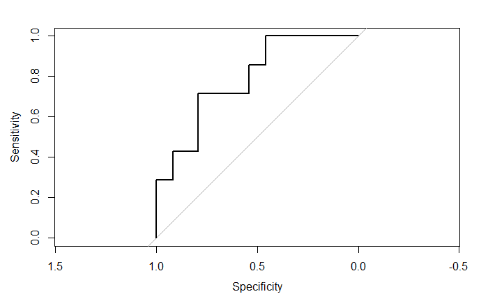

```r
roc_object <- roc(validationSet$y, prediction$prob[,2])
plot.roc(roc_object)
```

```r
auc(roc_object)
```

```
Area under the curve: 0.7857
```

```r
x1 <- 3.45
x2 <- 1
x3 <- 18
x4 <- 5.8
myScoreData <- data.frame(x1, x2, x3, x4)
myScoreData <- data.frame(myScoreData)
predicted_class_score <- predict(boosting_tree, myScoreData)
predicted_class_score$class
```

```
[1] "0"
```

```r
predicted_class_score$prob
```

```
          [,1]      [,2]
[1,] 0.6696016 0.3303984
```

### 10.7

```r
myData = read_xlsx("Ch10_Q46_Data_File.xlsx")
```

Preliminary work:

```r
myData$y <- as.factor(myData$y)
set.seed(1)
myIndex <- createDataPartition(myData$y, p=0.6, list=FALSE)
trainSet <- myData[myIndex,]
validationSet <- myData[-myIndex,]
set.seed(1)
```

We have four predictor variables, but want to create a random forest ensemble model using only two variables in each tree. All four variables will still be used in the aggregated tree, but each iteration will use a random pair of variables to generate the tree.

```r
randomforest_tree <- randomForest(y ~., data = trainSet, ntree = 100, mtry = 2, importance = TRUE)
predicted_class <- predict(randomforest_tree, validationSet)
confusionMatrix(predicted_class, validationSet$y, positive = "1")
```

```
Confusion Matrix and Statistics

          Reference
Prediction  0  1
         0 24  3
         1  1  3

               Accuracy : 0.871
                 95% CI : (0.7017, 0.9637)
    No Information Rate : 0.8065
    P-Value [Acc > NIR] : 0.2563

                  Kappa : 0.5267

 Mcnemar's Test P-Value : 0.6171

            Sensitivity : 0.50000
            Specificity : 0.96000
         Pos Pred Value : 0.75000
         Neg Pred Value : 0.88889
             Prevalence : 0.19355
         Detection Rate : 0.09677
   Detection Prevalence : 0.12903
      Balanced Accuracy : 0.73000

       'Positive' Class : 1
```

Predict validation set probabilities, plot ROC curve, and compute AUC.

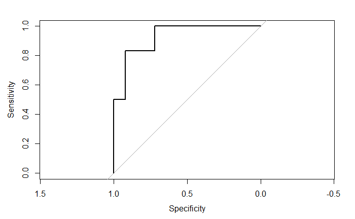

```r
predicted_prob <- predict(randomforest_tree, newdata=validationSet, type= 'prob')
roc_object <- roc(validationSet$y, predicted_prob[,2])
plot.roc(roc_object)
```

```r
auc(roc_object)
```

```
Area under the curve: 0.9267
```

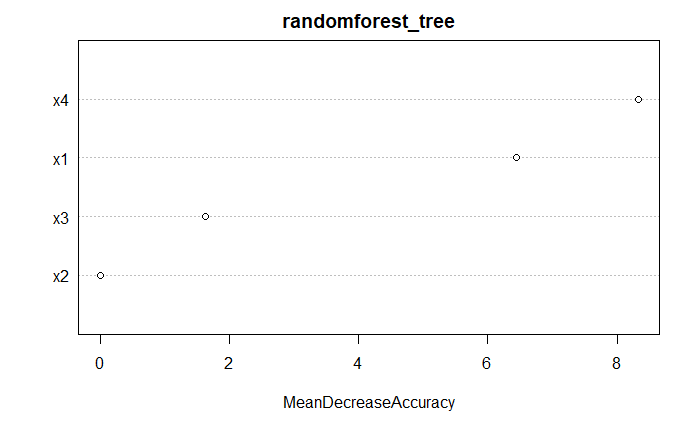

```r
varImpPlot(randomforest_tree, type=1)
```

Score new observation and estimate score value and probability.

```r
x1 <- 3.45
x2 <- 1
x3 <- 18
x4 <- 5.8
myScoreData <- data.frame(x1, x2, x3, x4)
predicted_class_score <- predict(randomforest_tree, myScoreData, type = "class")
predicted_class_score
```

```
1
0
Levels: 0 1
```

```r
predicted_class_prob <- predict(randomforest_tree, myScoreData, type = "prob")
predicted_class_prob
```

```
     0    1
1 0.69 0.31
attr(,"class")
[1] "matrix" "array"  "votes"
```

### 10.8

```r
myData = read_xlsx("Ch10_Q55_Data_File.xlsx")
```

Context: We are developing a predictive model to identify credit card fraud. The dataset that we have available to train the model has 200 observations of four variables. The dependent variable is an indicator for observed instances of fraud (13/200=6.5%). The available predictor variables are Amount (a categorical variable indicating the size of the transaction with 3 categories: low, medium, and high, which have transitivity), Online (a dummy variable indicating whether the transaction took place online), and Prior (an indicator if the cardholder has previously purchased this product).

Preliminary work:

```r
myData$Fraud <- as.factor(myData$Fraud)
set.seed(1)
myIndex <- createDataPartition(myData$Fraud, p=0.6, list=FALSE)
trainSet <- myData[myIndex,]
validationSet <- myData[-myIndex,]
set.seed(1)
```

Create bagging model using randomForest on all 3 predictor variables. Then predict validation set and compute confusion matrix.

```r
bagging_tree <- randomForest(Fraud ~., data = trainSet, ntree = 100, mtry = 3, importance = TRUE)
predicted_class <- predict(bagging_tree, validationSet)
confusionMatrix(predicted_class, validationSet$Fraud, positive = "1")
```

```
Confusion Matrix and Statistics

          Reference
Prediction  0  1
         0 69  4
         1  5  1

               Accuracy : 0.8861
                 95% CI : (0.7947, 0.9466)
    No Information Rate : 0.9367
    P-Value [Acc > NIR] : 0.9728

                  Kappa : 0.1211

 Mcnemar's Test P-Value : 1.0000

            Sensitivity : 0.20000
            Specificity : 0.93243
         Pos Pred Value : 0.16667
         Neg Pred Value : 0.94521
             Prevalence : 0.06329
         Detection Rate : 0.01266
   Detection Prevalence : 0.07595
      Balanced Accuracy : 0.56622

       'Positive' Class : 1
```

So this bagging model correctly predicts 89% of the validation set outcomes. Is this good? Well, since the validation dataset only had 6.3% (5/79) fraudulent transactions, if we just took the naive approach and classified everything as a clean transaction, then we would expect about 94% accuracy. If we look at the sensitivity of 0.2, this examines how many of the actual fraudulent transactions the model correctly catches. So out of the 5 actual fraudulent transactions in the validation set, the bagging model only identifies 1 of them. In other words, it’s not very good.

Predict validation probabilities, plot ROC curve, and compute AUC.

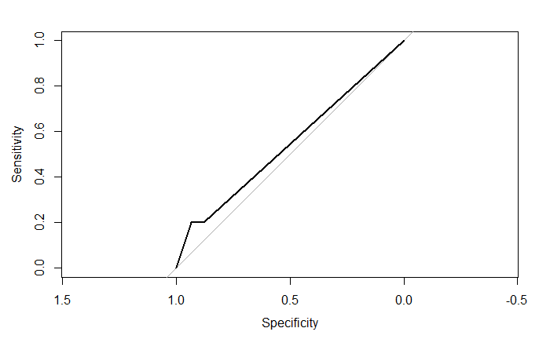

```r
predicted_prob <- predict(bagging_tree, validationSet, type= 'prob')
roc_object <- roc(validationSet$Fraud, predicted_prob[,2])
plot.roc(roc_object)
```

```r
auc(roc_object)
```

```
Area under the curve: 0.5446
```

As we see with the ROC and AUC, the bagging model is only marginally better than the baseline model of randomly guessing. This reiterates the point that this is not particularly effective given the small size of the dataset.

Create a random forest model using only two random predictors in each tree. Then predict validation set and compute confusion matrix.

```r
set.seed(1)
randomforest_tree <- randomForest(Fraud ~., data = trainSet, ntree = 100, mtry = 2, importance = TRUE)
predicted_class <- predict(randomforest_tree, validationSet)
confusionMatrix(predicted_class, validationSet$Fraud, positive = "1")
```

```
Confusion Matrix and Statistics

          Reference
Prediction  0  1
         0 74  5
         1  0  0

               Accuracy : 0.9367
                 95% CI : (0.8584, 0.9791)
    No Information Rate : 0.9367
    P-Value [Acc > NIR] : 0.61602

                  Kappa : 0

 Mcnemar's Test P-Value : 0.07364

            Sensitivity : 0.00000
            Specificity : 1.00000
         Pos Pred Value :     NaN
         Neg Pred Value : 0.93671
             Prevalence : 0.06329
         Detection Rate : 0.00000
   Detection Prevalence : 0.00000
      Balanced Accuracy : 0.50000

       'Positive' Class : 1
```

The random forest model with two predictor variables in each tree simply results in all validation set predictions being classified as not fraud. This essentially replicates the naive rule and has an accuracy of 93.7%.

So which model is better? Well if we look at accuracy, then the random forest outperforms the bagging model. But that treats Type I and Type II errors as equally costly. In the fraud examination space, it is far more costly to miss a fraudulent transaction than it is to flag a legitimate transaction. This means the cost of a Type II error (incorrectly labeling a fraudulent transaction as not be fraud) is far more costly than a Type I error (incorrectly flagging a non-fraud transaction).

So in this context, we are better off comparing the sensitivities of the two models. The sensitivities compare what percentage of the actual fraudulent transactions in the validation set that are correctly identified as fraud. Thus, the sensitivity of 0.2 in the bagging model outperforms the 0.0 sensitivity of the random forest model. In general, I’d say the conclusion is that both models perform poorly at identifying fraud out-of-sample, but the bagging model is slightly less bad than the random forest model.

Predict validation probabilities, plot ROC curve, and compute AUC. Also, plot the variable importance chart.

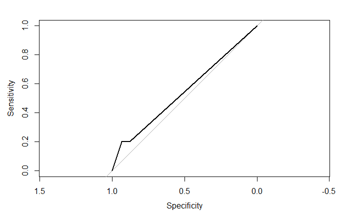

```r
predicted_prob <- predict(randomforest_tree, validationSet, type= 'prob')
roc_object <- roc(validationSet$Fraud, predicted_prob[,2])
plot.roc(roc_object)
```

```r
auc(roc_object)
```

```
Area under the curve: 0.5446
```

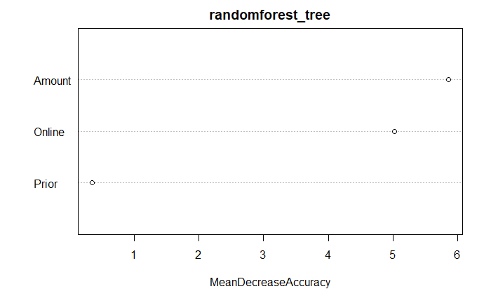

```r
varImpPlot(randomforest_tree, type=1)
```

```r
predicted_prob <- predict(bagging_tree, validationSet, type='prob')
validationSet$Fraud <- as.numeric(as.character(validationSet$Fraud))
gains_table <- gains(validationSet$Fraud, predicted_prob[,2])
gains_table
```

```
Depth                            Cume   Cume Pct                     Mean
 of           Cume     Mean      Mean   of Total    Lift   Cume     Model
File     N      N      Resp      Resp      Resp    Index   Lift     Score
-------------------------------------------------------------------------
   8     6      6      0.17      0.17      20.0%     263    263      0.60
  13     4     10      0.00      0.10      20.0%       0    158      0.06
 100    69     79      0.06      0.06     100.0%      92    100      0.00
```

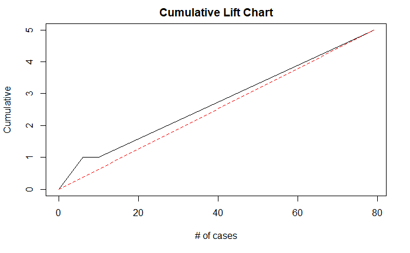

```r
plot(c(0, gains_table$cume.pct.of.total*sum(validationSet$Fraud))~c(0, gains_table$cume.obs), xlab = "# of cases", ylab = "Cumulative", main="Cumulative Lift Chart", type="l")
lines(c(0, sum(validationSet$Fraud))~c(0, dim(validationSet)[1]), col="red", lty=2)
```

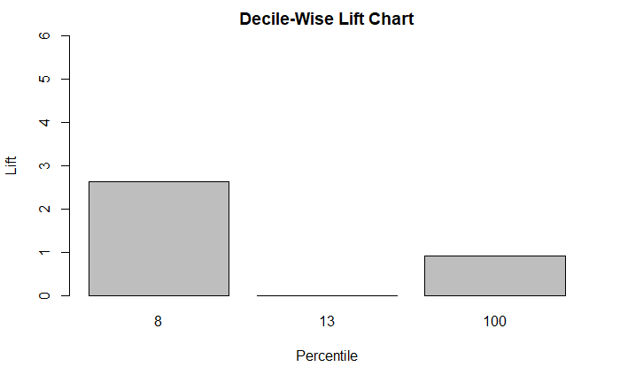

```r
barplot(gains_table$mean.resp/mean(validationSet$Fraud), names.arg=gains_table$depth, xlab="Percentile", ylab="Lift", ylim=c(0,6), main="Decile-Wise Lift Chart")
```

```r
# Decile-Wise Lift Chart for the random trees model
predicted_prob <- predict(randomforest_tree, validationSet, type='prob')
validationSet$Fraud <- as.numeric(as.character(validationSet$Fraud))
gains_table <- gains(validationSet$Fraud, predicted_prob[,2])
gains_table
```

```
Depth                            Cume   Cume Pct                     Mean
 of           Cume     Mean      Mean   of Total    Lift   Cume     Model
File     N      N      Resp      Resp      Resp    Index   Lift     Score
-------------------------------------------------------------------------
   8     6      6      0.17      0.17      20.0%     263    263      0.47
  13     4     10      0.00      0.10      20.0%       0    158      0.10
 100    69     79      0.06      0.06     100.0%      92    100      0.00
```

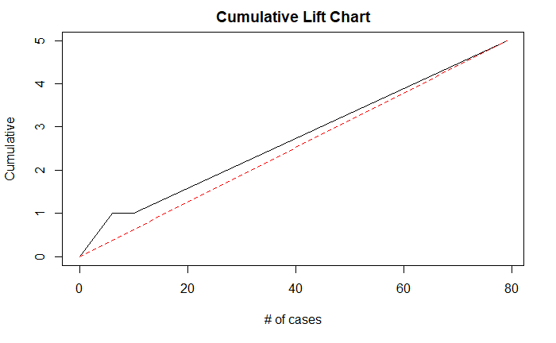

```r
plot(c(0, gains_table$cume.pct.of.total*sum(validationSet$Fraud))~c(0, gains_table$cume.obs), xlab = "# of cases", ylab = "Cumulative", main="Cumulative Lift Chart", type="l")
lines(c(0, sum(validationSet$Fraud))~c(0, dim(validationSet)[1]), col="red", lty=2)
```

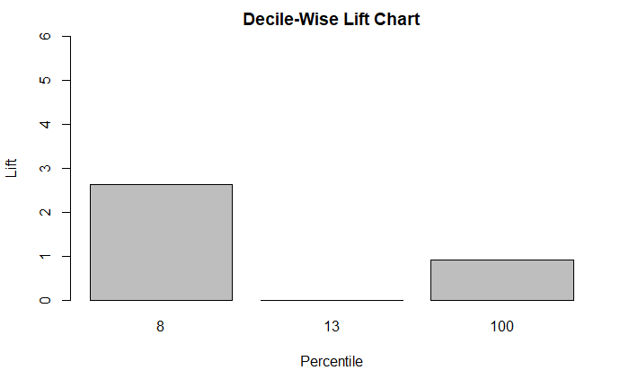

```r
barplot(gains_table$mean.resp/mean(validationSet$Fraud), names.arg=gains_table$depth, xlab="Percentile", ylab="Lift", ylim=c(0,6), main="Decile-Wise Lift Chart")
```

### 10.9

```r
myData = read_xlsx("Ch10_Q52_Data_File.xlsx")
```

Preliminary work:

```r
myData$Disease <- as.factor(myData$Disease)
set.seed(1)
myIndex <- createDataPartition(myData$Disease, p=0.6, list=FALSE)
trainSet <- myData[myIndex,]
validationSet <- myData[-myIndex,]
set.seed(1)
```

Create bagging model using randomForest with all four predictors.

```r
bagging_tree <- randomForest(Disease ~., data = trainSet, ntree = 100, mtry = 4, importance = TRUE)
predicted_class <- predict(bagging_tree, validationSet)
confusionMatrix(predicted_class, validationSet$Disease, positive = "1")
```

```
Confusion Matrix and Statistics

          Reference
Prediction  0  1
         0 22 14
         1  7 28

               Accuracy : 0.7042
                 95% CI : (0.5841, 0.8067)
    No Information Rate : 0.5915
    P-Value [Acc > NIR] : 0.03335

                  Kappa : 0.41

 Mcnemar's Test P-Value : 0.19043

            Sensitivity : 0.6667
            Specificity : 0.7586
         Pos Pred Value : 0.8000
         Neg Pred Value : 0.6111
             Prevalence : 0.5915
         Detection Rate : 0.3944
   Detection Prevalence : 0.4930
      Balanced Accuracy : 0.7126

       'Positive' Class : 1
```

Create boosting model to compete with bagging model. *Note: this one seems to end in an endless loop and doesn’t compute. See v2 for one that works with the other rng.

```r
set.seed(1)
boosting_tree <- boosting(Disease ~ ., data = trainSet, mfinal = 100)
```

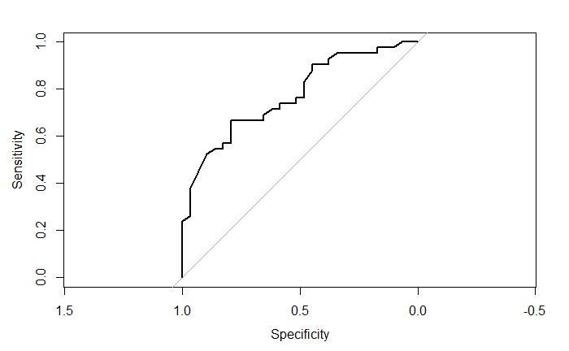

```r
predicted_prob <- predict(bagging_tree, validationSet, type= 'prob')
roc_object <- roc(validationSet$Disease, predicted_prob[,2])
plot.roc(roc_object)
```

```r
auc(roc_object)
```

```
Area under the curve: 0.7738
```

```r
roc_object <- roc(validationSet$Disease, prediction$prob[,2])
```

[output not shown]